# hw05

## 7)

Для начала, нам нужно решить задачу аналитически.

$$-u''(x) + u(x) = x,\;\;0 \leqslant x \leqslant 1,\;\;u(0) = u(1) = 0$$

Рассмотрим соответствующее однородное уравнение.

$$-u''(x) + u(x) = 0$$$$x^2 - 1 = 0$$

Корни $x \in \{-1, 1\}$, оба кратности один.

Тогда общее решение имеет вид $$c_1 e^{x} + c_2 e^{-x}$$

Возвращаемся к исходному неоднородному.

Рассмотрим частное решение $u(x) = x$ неоднородного уравнения

$$-u''(x) + u(x) = x$$

Мы можем получть общее решение неоднородного урванения как сумму общего решения однородного и частного решения неоднородного, тем самым общее решение неоднородного имеет вид:

$$c_1 e^{x} + c_2 e^{-x} + x$$

Осталось подобрать константы (подставим точки x = 0, x = 1):

\begin{equation*} \begin{cases} c_1 + c_2 = 0 \\ c_1 e + \frac{c_2}{e} = -1 \end{cases} \Leftrightarrow \begin{cases} c_2 = -c_1 \\ c_1 e + \frac{c_2}{e} = -1 \end{cases} \Leftrightarrow \begin{cases} c_1 = \frac{1}{\frac{1}{e} - e} \\ c_2 = \frac{-1}{\frac{1}{e} - e} \end{cases} \end{equation*}

Итого:

$$u(x) = \frac{1}{\frac{1}{e} - e} \cdot (e^x - e^{-x}) + x = \frac{e \cdot (e^{x} - e^{-x})}{1 - e^2} + x$$

Теперь опишем функцию для нахождения точного решения:

```python
import numpy as np

def get_u(x):
    return x + (np.exp(1 + x) - np.exp(1 - x)) / (1 - np.exp(2))
```

Теперь опишем функции для нахождения $A$ и $b$ (мы помним, что $u(0) = u(1) = 0$, а стало быть

$$u(x_0) = u(x_{N + 1}) = 0$$

и матрица $A$ действительно будет трехдиагональной).

```python
def get_A(N):
    h = 1.0 / (N + 1)
    A = []
    for i in range(N):
        current = []
        for j in range(i - 1):
            current.append(0)
        if i > 0:
            current.append(-h**(-2))
        current.append(2 * h**(-2) + 1)
        if i < N - 1:
            current.append(-h**(-2))
        for j in range(N - i - 2):
            current.append(0)
        A.append(current)
    return np.array(A)
```

```python
get_A(4)
```

```
array([[ 51., -25.,   0.,   0.],
       [-25.,  51., -25.,   0.],
       [  0., -25.,  51., -25.],
       [  0.,   0., -25.,  51.]])
```

```python
def get_b(N):
    h = 1.0 / (N + 1)
    return np.array([h * i for i in range(1, N + 1)])
```

```python
get_b(4)
```

```
array([0.2, 0.4, 0.6, 0.8])
```

В качестве стандартного способа решать СЛАУ рассмотрим numpy.linalg.solve. Также скопируем функцию для постороения графиков из предыдущих домашек.

```python
import matplotlib.pyplot as plt

def build_plot(xs, ys, xlabel='', ylabel='', title='', filename='plot',
               plot_labels=None, color_shapes=None, points=None):
    xs = np.array(xs)
    ys = np.array(ys)
    if xs.ndim == 1:
        xs = np.array([xs])
        ys = np.array([ys])
    if color_shapes is None:
        color_shapes = ['' for _ in range(xs.shape[0] if xs.ndim > 1 else 1)]

    plt.clf()
    if points is not None:
        plt.plot(points[0], points[1], 'ro')
    plt.xlabel(xlabel)
    plt.ylabel(ylabel)
    plt.title(title)
    for ind, (x, y) in enumerate(zip(xs, ys)):
        if plot_labels is not None:
            plt.plot(x, y, color_shapes[ind], label=plot_labels[ind])
        else:
            plt.plot(x, y, color_shapes[ind])
    if plot_labels is not None:
        plt.legend()
    plt.show()
```

```python
def get_u_vector_standart_solver(N):
    A = get_A(N)
    b = get_b(N)
    return np.linalg.solve(A, b)

def get_u_vector(N):
    h = 1.0 / (N + 1)
    return np.array([get_u(h * i) for i in range(1, N + 1)])
```

Построим график зависимости погрешшности от $N$. Погрешность будем рассматривать, как максимум погрешности в точках $x_i$.

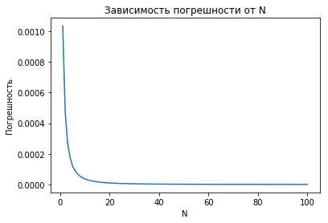

```python
Ns = range(1, 101)
build_plot(Ns, [np.amax(np.abs(get_u_vector_standart_solver(N) - get_u_vector(N))) for N in Ns],
           'N', 'Погрешность', 'Зависимость погрешности от N')
```

Как видим, погрешность (неточность) не существенная.

Реализуем метод прогонки.

Для начала, заметим, что в нашем случае

$$2h^{-2} + 1 = |c_i| > |a_i| + |b_i| = 2h^2,$$

то есть выполняется достаточное условие разрешимости прогонки.

```python
def tridiagonal_algo_solver(a, b, c, d):
    N = len(a)
    alphas = [b[0] / c[0]]
    betas = [d[0] / c[0]]
    for i in range(N - 1):
        alphas.append(b[i + 1] / (c[i + 1] - alphas[-1] * a[i + 1]))
        betas.append((d[i + 1] + betas[-1] * a[i + 1]) / (c[i + 1] - alphas[-1] * a[i + 1]))
    ans = [0 for _ in range(N)]
    ans[N - 1] = betas[-1]
    for i in range(N - 2, -1, -1):
        ans[i] = ans[i + 1] * alphas[i] + betas[i]
    return np.array(ans)
```

```python
def get_u_vector_tridiagonal_algo_solver(N):
    h = 1.0 / (N + 1)
    a = [h**(-2) for _ in range(N)]
    b = [h**(-2) for _ in range(N)]
    c = [2 * h**(-2) + 1 for _ in range(N)]
    d = get_b(N)
    return tridiagonal_algo_solver(a, b, c, d)
```

Построим график зависимости погрешности от $N$

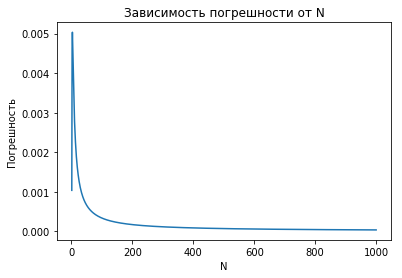

```python
Ns = range(1, 1001)
build_plot(Ns, [np.amax(np.abs(get_u_vector_tridiagonal_algo_solver(N) - get_u_vector(N))) for N in Ns],
           'N', 'Погрешность', 'Зависимость погрешности от N')
```

Теперь стоит построить график зависимости времени работы от $N$ для обоих подходов и сравнить.

```python
import time

def get_time(approach, N):
    current_time = time.time()
    _ = approach(N)
    return (time.time() - current_time) * 1000 # in milliseconds
```

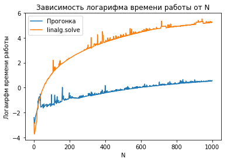

```python
Ns = range(1, 1001)
build_plot([Ns, Ns],
           [[np.log(get_time(get_u_vector_tridiagonal_algo_solver, N)) for N in Ns],
            [np.log(get_time(get_u_vector_standart_solver, N)) for N in Ns]],
          'N', 'Логаирфм времени работы', 'Зависимость логарифма времени работы от N', plot_labels=['Прогонка', 'linalg.solve'])
```

Как несложно заметить, прогонка работает быстрее. Это можня связать например с тем, что прогонка явно использует, что матрица имеет вполне определенный вид (трехдиагональный) и не только ассимптотически лучше (сложность алгоритма по времени $\mathcal{O}(N)$), но что важно совершает меньше операций с вещественными числами (линейное число). Также прогонка требует и по памяти лишь линейное количество затрат. `numpy` вызывает один из методов `LAPACK`, этот метод не оптимизирован для работы с такими матрицами. Число операций может быть порядка $N^2$ (против нашего линейного).

Вообще, `scipy` умеет работать с разряженными матрицами, а для решения уравнений с его помощью предлагается использовать `scipy.linalg.solve_banded`

Ради интереса, посмотрим что будет происходить с таким подходом.

```python
from scipy.linalg import solve_banded

def get_ab(A, N):
    ab = [[0 for _ in range(N)] for _ in range(3)]

    for i in range(N):
        if i != 0:
            ab[0][i] = A[i - 1][i]
        ab[1][i] = A[i][i]
        if i != N - 1:
            ab[2][i] = A[i + 1][i]

    return np.array(ab)

def get_u_vector_banded_solver(N):
    A = get_A(N)
    ab = get_ab(A, N)
    b = get_b(N)
    return solve_banded((1, 1), ab, b)
```

```python
N = 5
A = get_A(N)
print(get_ab(A, N))
```

```
[[  0. -36. -36. -36. -36.]
 [ 73.  73.  73.  73.  73.]
 [-36. -36. -36. -36.   0.]]
```

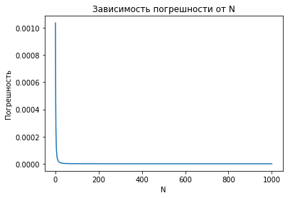

```python
Ns = range(1, 1001)
build_plot(Ns, [np.amax(np.abs(get_u_vector_banded_solver(N) - get_u_vector(N))) for N in Ns],
           'N', 'Погрешность', 'Зависимость погрешности от N')
```

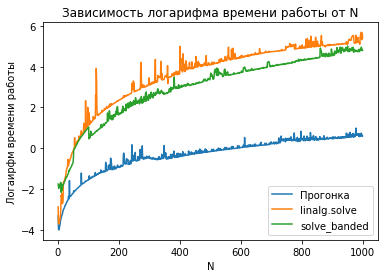

```python
Ns = range(1, 1001)
build_plot([Ns, Ns, Ns],
           [[np.log(get_time(get_u_vector_tridiagonal_algo_solver, N)) for N in Ns],
            [np.log(get_time(get_u_vector_standart_solver, N)) for N in Ns],
            [np.log(get_time(get_u_vector_banded_solver, N)) for N in Ns]],
          'N', 'Логаирфм времени работы', 'Зависимость логарифма времени работы от N', plot_labels=['Прогонка',
                                                                                                    'linalg.solve',
                                                                                                    'solve_banded'])
```

Получили, что `solve_banded` работает немного лучше, чем `numpy.linalg`, но хуже прогонки. Это кажется понятным: мы используем вид матрицы, но banded шире, чем трехдиагональные, методы там другие.

```
Band matrix is a sparse matrix whose non-zero entries are confined to a diagonal band, comprising the main diagonal and zero or more diagonals on either side
```

## 8)

Начнем с нулевого вектора. Опишем фунекцию, которая принимает количество итераций (и возвращает все промежуточные вектора $x$):

```python
def SOR(A, b, N, iter_number, w):
    xs_intermed = []
    xs = [0 for _ in range(N)]
    for _ in range(iter_number):
        xs_new = []
        for i in range(N):
            xs_new.append((1 - w) * xs[i] + w * (b[i] -
                                                sum([A[i][j] * xs_new[j] for j in range(i)]) -
                                                sum([A[i][j] * xs[j] for j in range(i + 1, N)])) / A[i][i])
        xs_intermed.append(xs_new)
        xs = [x for x in xs_new]
    return xs_intermed
```

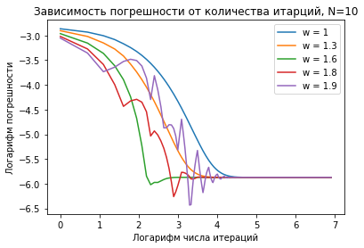

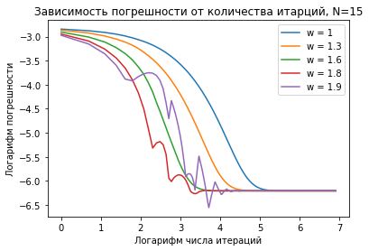

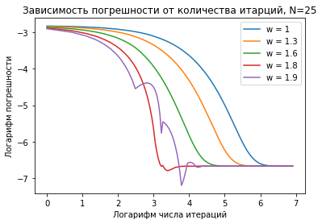

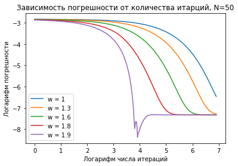

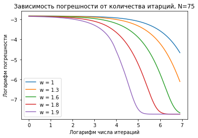

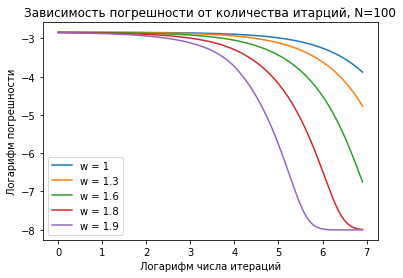

```python
for N in [10, 15, 25, 50, 75, 100]:
    ws = [1, 1.3, 1.6, 1.8, 1.9]
    iters_number = 1000
    A = get_A(N)
    b = get_b(N)
    Ns = range(1, iters_number + 1)
    build_plot([np.log(Ns) for _ in ws],
               [np.log([np.amax(np.abs(x - get_u_vector_tridiagonal_algo_solver(N))) for x in SOR(A, b, N, iters_number, w)])
                   for w in ws],
              'Логарифм числа итераций', 'Логарифм погрешности', 'Зависимость погрешности от количества итарций, N={N}'.format(N=N),
               plot_labels=['w = {w}'.format(w=w) for w in ws])
```

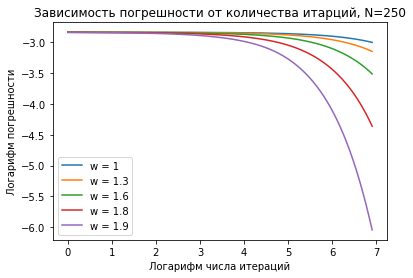

```python
N = 250
ws = [1, 1.3, 1.6, 1.8, 1.9]
iters_number = 1000
A = get_A(N)
b = get_b(N)
Ns = range(1, iters_number + 1)
build_plot([np.log(Ns) for _ in ws],
           [np.log([np.amax(np.abs(x - get_u_vector_tridiagonal_algo_solver(N))) for x in SOR(A, b, N, iters_number, w)])
               for w in ws],
          'Логарифм числа итераций', 'Логарифм погрешности', 'Зависимость погрешности от количества итарций, N={N}'.format(N=N),
           plot_labels=['w = {w}'.format(w=w) for w in ws])
```

Похоже, что действительно стоит брать $\omega = 1.9$